# Analysis of the types of change present in Apache’s sentry codebase over time

Fabián Santander

7/7/2021

## Sentry data

This is a change analysis between files changed in commits of the project sentry by Apache. See: https://github.com/apache/sentry.

The data generated looks like:

Sentry distilled commits

| filename | change | change_level | level_name | change_start_byte | change_end_byte | line_number | commit_1 | commit_2 | change_content |
| --- | --- | --- | --- | --- | --- | --- | --- | --- | --- |
| HiveAuthzBindingHookBase.java | STATEMENT_INSERT | METHOD | org.apache.sentry.binding.hive.authz.HiveAuthzBindingHookBase.getPrivilegeCache(Set<String>,PrivilegeFactory) | 37839 | 38032 | 875 | f5cad4fb15fa9b3aaf9d691e2df3065860b11353 | 843368fc2aeb154f9cf7b18d191c128644295ce5 | (cacheConstructor != null) |
| HiveAuthzBindingHookBase.java | STATEMENT_INSERT | METHOD | org.apache.sentry.binding.hive.authz.HiveAuthzBindingHookBase.getPrivilegeCache(Set<String>,PrivilegeFactory) | 38117 | 38203 | 882 | f5cad4fb15fa9b3aaf9d691e2df3065860b11353 | 843368fc2aeb154f9cf7b18d191c128644295ce5 | cacheConstructor = Class.forName(privilegeCacheName).getDeclaredConstructor(Set.class); |
| HiveAuthzBindingHookBase.java | STATEMENT_DELETE | METHOD | org.apache.sentry.binding.hive.authz.HiveAuthzBindingHookBase.getPrivilegeCache(Set<String>,PrivilegeFactory) | 38121 | 38222 | 882 | f5cad4fb15fa9b3aaf9d691e2df3065860b11353 | 843368fc2aeb154f9cf7b18d191c128644295ce5 | Constructor<?> cacheConstructor = Class.forName(privilegeCacheName).getDeclaredConstructor(Set.class); |
| HiveAuthzBindingHookBase.java | STATEMENT_DELETE | METHOD | org.apache.sentry.binding.hive.authz.HiveAuthzBindingHookBase.getPrivilegeCache(Set<String>,PrivilegeFactory) | 38399 | 38471 | 887 | f5cad4fb15fa9b3aaf9d691e2df3065860b11353 | 843368fc2aeb154f9cf7b18d191c128644295ce5 | LOG.error(“Exception at creating privilege cache after second try”, ex2); |
| HiveAuthzBindingHookBase.java | STATEMENT_DELETE | METHOD | org.apache.sentry.binding.hive.authz.HiveAuthzBindingHookBase.getPrivilegeCache(Set<String>,PrivilegeFactory) | 37988 | 38503 | 878 | f5cad4fb15fa9b3aaf9d691e2df3065860b11353 | 843368fc2aeb154f9cf7b18d191c128644295ce5 | NoSuchMethodException |
| HiveAuthzBindingHookBase.java | STATEMENT_DELETE | METHOD | org.apache.sentry.binding.hive.authz.HiveAuthzBindingHookBase.getPrivilegeCache(Set<String>,PrivilegeFactory) | 38596 | 38604 | 894 | f5cad4fb15fa9b3aaf9d691e2df3065860b11353 | 843368fc2aeb154f9cf7b18d191c128644295ce5 | ex; |
| HiveAuthzBindingHookBase.java | STATEMENT_DELETE | METHOD | org.apache.sentry.binding.hive.authz.HiveAuthzBindingHookBase.getPrivilegeCache(Set<String>,PrivilegeFactory) | 38505 | 38610 | 892 | f5cad4fb15fa9b3aaf9d691e2df3065860b11353 | 843368fc2aeb154f9cf7b18d191c128644295ce5 | Exception |
| HiveAuthzBindingHookBase.java | STATEMENT_DELETE | METHOD | org.apache.sentry.binding.hive.authz.HiveAuthzBindingHookBase.getPrivilegeCache(Set<String>,PrivilegeFactory) | 37608 | 38610 | 871 | f5cad4fb15fa9b3aaf9d691e2df3065860b11353 | 843368fc2aeb154f9cf7b18d191c128644295ce5 | NA |
| HiveAuthzBindingHookBase.java | STATEMENT_PARENT_CHANGE | METHOD | org.apache.sentry.binding.hive.authz.HiveAuthzBindingHookBase.getPrivilegeCache(Set<String>,PrivilegeFactory) | 38029 | 38497 | 879 | f5cad4fb15fa9b3aaf9d691e2df3065860b11353 | 843368fc2aeb154f9cf7b18d191c128644295ce5 | NA |
| HiveAuthzBindingHookBase.java | COMMENT_MOVE | METHOD | org.apache.sentry.binding.hive.authz.HiveAuthzBindingHookBase.getPrivilegeCache(Set<String>,PrivilegeFactory) | 38043 | 38112 | 881 | f5cad4fb15fa9b3aaf9d691e2df3065860b11353 | 843368fc2aeb154f9cf7b18d191c128644295ce5 | // load the privilege cache class that does not use privilege factory |
| HiveAuthzBindingHookBase.java | STATEMENT_ORDERING_CHANGE | METHOD | org.apache.sentry.binding.hive.authz.HiveAuthzBindingHookBase.getPrivilegeCache(Set<String>,PrivilegeFactory) | 38232 | 38268 | 883 | f5cad4fb15fa9b3aaf9d691e2df3065860b11353 | 843368fc2aeb154f9cf7b18d191c128644295ce5 | cacheConstructor.setAccessible(true); |
| HiveAuthzBindingHookBase.java | STATEMENT_ORDERING_CHANGE | METHOD | org.apache.sentry.binding.hive.authz.HiveAuthzBindingHookBase.getPrivilegeCache(Set<String>,PrivilegeFactory) | 38278 | 38357 | 884 | f5cad4fb15fa9b3aaf9d691e2df3065860b11353 | 843368fc2aeb154f9cf7b18d191c128644295ce5 | (PrivilegeCache) cacheConstructor.newInstance(userPrivileges); |
| HiveAuthzBindingHookBase.java | STATEMENT_ORDERING_CHANGE | METHOD | org.apache.sentry.binding.hive.authz.HiveAuthzBindingHookBase.getPrivilegeCache(Set<String>,PrivilegeFactory) | 38534 | 38588 | 892 | f5cad4fb15fa9b3aaf9d691e2df3065860b11353 | 843368fc2aeb154f9cf7b18d191c128644295ce5 | LOG.error(“Exception at creating privilege cache”, ex); |
| HiveAuthzBindingHookBase.java | STATEMENT_PARENT_CHANGE | METHOD | org.apache.sentry.binding.hive.authz.HiveAuthzBindingHookBase.getPrivilegeCache(Set<String>,PrivilegeFactory) | 37839 | 37875 | 875 | f5cad4fb15fa9b3aaf9d691e2df3065860b11353 | 843368fc2aeb154f9cf7b18d191c128644295ce5 | cacheConstructor.setAccessible(true); |
| HiveAuthzBindingHookBase.java | STATEMENT_PARENT_CHANGE | METHOD | org.apache.sentry.binding.hive.authz.HiveAuthzBindingHookBase.getPrivilegeCache(Set<String>,PrivilegeFactory) | 37883 | 37980 | 876 | f5cad4fb15fa9b3aaf9d691e2df3065860b11353 | 843368fc2aeb154f9cf7b18d191c128644295ce5 | (PrivilegeCache) cacheConstructor.newInstance(userPrivileges, inPrivilegeFactory); |
| MetastoreAuthzBindingBase.java | STATEMENT_INSERT | METHOD | org.apache.sentry.binding.metastore.MetastoreAuthzBindingBase.getPrivilegeCache(Set<String>,PrivilegeFactory) | 22175 | 22368 | 534 | f5cad4fb15fa9b3aaf9d691e2df3065860b11353 | 843368fc2aeb154f9cf7b18d191c128644295ce5 | (cacheConstructor != null) |
| MetastoreAuthzBindingBase.java | STATEMENT_INSERT | METHOD | org.apache.sentry.binding.metastore.MetastoreAuthzBindingBase.getPrivilegeCache(Set<String>,PrivilegeFactory) | 22453 | 22539 | 541 | f5cad4fb15fa9b3aaf9d691e2df3065860b11353 | 843368fc2aeb154f9cf7b18d191c128644295ce5 | cacheConstructor = Class.forName(privilegeCacheName).getDeclaredConstructor(Set.class); |
| MetastoreAuthzBindingBase.java | STATEMENT_DELETE | METHOD | org.apache.sentry.binding.metastore.MetastoreAuthzBindingBase.getPrivilegeCache(Set<String>,PrivilegeFactory) | 22457 | 22558 | 541 | f5cad4fb15fa9b3aaf9d691e2df3065860b11353 | 843368fc2aeb154f9cf7b18d191c128644295ce5 | Constructor<?> cacheConstructor = Class.forName(privilegeCacheName).getDeclaredConstructor(Set.class); |
| MetastoreAuthzBindingBase.java | STATEMENT_DELETE | METHOD | org.apache.sentry.binding.metastore.MetastoreAuthzBindingBase.getPrivilegeCache(Set<String>,PrivilegeFactory) | 22735 | 22807 | 546 | f5cad4fb15fa9b3aaf9d691e2df3065860b11353 | 843368fc2aeb154f9cf7b18d191c128644295ce5 | LOG.error(“Exception at creating privilege cache after second try”, ex2); |
| MetastoreAuthzBindingBase.java | STATEMENT_DELETE | METHOD | org.apache.sentry.binding.metastore.MetastoreAuthzBindingBase.getPrivilegeCache(Set<String>,PrivilegeFactory) | 22324 | 22839 | 537 | f5cad4fb15fa9b3aaf9d691e2df3065860b11353 | 843368fc2aeb154f9cf7b18d191c128644295ce5 | NoSuchMethodException |
| MetastoreAuthzBindingBase.java | STATEMENT_DELETE | METHOD | org.apache.sentry.binding.metastore.MetastoreAuthzBindingBase.getPrivilegeCache(Set<String>,PrivilegeFactory) | 22932 | 22940 | 557 | f5cad4fb15fa9b3aaf9d691e2df3065860b11353 | 843368fc2aeb154f9cf7b18d191c128644295ce5 | ex; |
| MetastoreAuthzBindingBase.java | STATEMENT_DELETE | METHOD | org.apache.sentry.binding.metastore.MetastoreAuthzBindingBase.getPrivilegeCache(Set<String>,PrivilegeFactory) | 22841 | 22946 | 552 | f5cad4fb15fa9b3aaf9d691e2df3065860b11353 | 843368fc2aeb154f9cf7b18d191c128644295ce5 | Exception |
| MetastoreAuthzBindingBase.java | STATEMENT_DELETE | METHOD | org.apache.sentry.binding.metastore.MetastoreAuthzBindingBase.getPrivilegeCache(Set<String>,PrivilegeFactory) | 21944 | 22946 | 530 | f5cad4fb15fa9b3aaf9d691e2df3065860b11353 | 843368fc2aeb154f9cf7b18d191c128644295ce5 | NA |
| MetastoreAuthzBindingBase.java | STATEMENT_PARENT_CHANGE | METHOD | org.apache.sentry.binding.metastore.MetastoreAuthzBindingBase.getPrivilegeCache(Set<String>,PrivilegeFactory) | 22365 | 22833 | 538 | f5cad4fb15fa9b3aaf9d691e2df3065860b11353 | 843368fc2aeb154f9cf7b18d191c128644295ce5 | NA |
| MetastoreAuthzBindingBase.java | COMMENT_MOVE | METHOD | org.apache.sentry.binding.metastore.MetastoreAuthzBindingBase.getPrivilegeCache(Set<String>,PrivilegeFactory) | 22379 | 22448 | 540 | f5cad4fb15fa9b3aaf9d691e2df3065860b11353 | 843368fc2aeb154f9cf7b18d191c128644295ce5 | // load the privilege cache class that does not use privilege factory |
| MetastoreAuthzBindingBase.java | STATEMENT_ORDERING_CHANGE | METHOD | org.apache.sentry.binding.metastore.MetastoreAuthzBindingBase.getPrivilegeCache(Set<String>,PrivilegeFactory) | 22568 | 22604 | 542 | f5cad4fb15fa9b3aaf9d691e2df3065860b11353 | 843368fc2aeb154f9cf7b18d191c128644295ce5 | cacheConstructor.setAccessible(true); |
| MetastoreAuthzBindingBase.java | STATEMENT_ORDERING_CHANGE | METHOD | org.apache.sentry.binding.metastore.MetastoreAuthzBindingBase.getPrivilegeCache(Set<String>,PrivilegeFactory) | 22614 | 22693 | 543 | f5cad4fb15fa9b3aaf9d691e2df3065860b11353 | 843368fc2aeb154f9cf7b18d191c128644295ce5 | (PrivilegeCache) cacheConstructor.newInstance(userPrivileges); |
| MetastoreAuthzBindingBase.java | STATEMENT_ORDERING_CHANGE | METHOD | org.apache.sentry.binding.metastore.MetastoreAuthzBindingBase.getPrivilegeCache(Set<String>,PrivilegeFactory) | 22870 | 22924 | 554 | f5cad4fb15fa9b3aaf9d691e2df3065860b11353 | 843368fc2aeb154f9cf7b18d191c128644295ce5 | LOG.error(“Exception at creating privilege cache”, ex); |
| MetastoreAuthzBindingBase.java | STATEMENT_PARENT_CHANGE | METHOD | org.apache.sentry.binding.metastore.MetastoreAuthzBindingBase.getPrivilegeCache(Set<String>,PrivilegeFactory) | 22175 | 22211 | 534 | f5cad4fb15fa9b3aaf9d691e2df3065860b11353 | 843368fc2aeb154f9cf7b18d191c128644295ce5 | cacheConstructor.setAccessible(true); |
| MetastoreAuthzBindingBase.java | STATEMENT_PARENT_CHANGE | METHOD | org.apache.sentry.binding.metastore.MetastoreAuthzBindingBase.getPrivilegeCache(Set<String>,PrivilegeFactory) | 22219 | 22316 | 535 | f5cad4fb15fa9b3aaf9d691e2df3065860b11353 | 843368fc2aeb154f9cf7b18d191c128644295ce5 | (PrivilegeCache) cacheConstructor.newInstance(userPrivileges, inPrivilegeFactory); |
| HiveAuthzBinding.java | DOC_UPDATE | METHOD | org.apache.sentry.binding.hive.authz.HiveAuthzBinding.authorize(HiveOperation,HiveAuthzPrivileges,Subject,Set<List<DBModelAuthorizable>>,Set<List<DBModelAuthorizable>>) | 13676 | 13927 | 296 | 843368fc2aeb154f9cf7b18d191c128644295ce5 | 1a2a1ecb237dc2ef3c1e7d0ad11c36c1c374cd89 | /** * Validate the privilege for the given operation for the given subject * @param hiveOp * @param stmtAuthPrivileges * @param subject * @param inputHierarchyList * @param outputHierarchyList * @thro… |
| HiveAuthzBinding.java | REMOVED_FUNCTIONALITY | CLASS | org.apache.sentry.binding.hive.authz.HiveAuthzBinding | 11525 | 11640 | 251 | 843368fc2aeb154f9cf7b18d191c128644295ce5 | 1a2a1ecb237dc2ef3c1e7d0ad11c36c1c374cd89 | org.apache.sentry.binding.hive.authz.HiveAuthzBinding.getPrivilegeFactory() |
| HiveAuthzBindingHookBase.java | INCREASING_ACCESSIBILITY_CHANGE | FIELD | org.apache.sentry.binding.hive.authz.HiveAuthzBindingHookBase.authzConf : HiveAuthzConf | 4245 | 4253 | 90 | 843368fc2aeb154f9cf7b18d191c128644295ce5 | 1a2a1ecb237dc2ef3c1e7d0ad11c36c1c374cd89 | protected |
| HiveAuthzBindingHookBase.java | REMOVING_ATTRIBUTE_MODIFIABILITY | FIELD | org.apache.sentry.binding.hive.authz.HiveAuthzBindingHookBase.authzConf : HiveAuthzConf | 4255 | 4259 | 90 | 843368fc2aeb154f9cf7b18d191c128644295ce5 | 1a2a1ecb237dc2ef3c1e7d0ad11c36c1c374cd89 | final |
| HiveAuthzBindingHookBase.java | UNCLASSIFIED_CHANGE | FIELD | org.apache.sentry.binding.hive.authz.HiveAuthzBindingHookBase.authzConf : HiveAuthzConf | 4350 | 4355 | 92 | 843368fc2aeb154f9cf7b18d191c128644295ce5 | 1a2a1ecb237dc2ef3c1e7d0ad11c36c1c374cd89 | static |
| HiveAuthzBindingHookBase.java | STATEMENT_INSERT | METHOD | org.apache.sentry.binding.hive.authz.HiveAuthzBindingHookBase.getHiveBindingWithPrivilegeCache(HiveAuthzBinding,String) | 36625 | 36697 | 852 | 843368fc2aeb154f9cf7b18d191c128644295ce5 | 1a2a1ecb237dc2ef3c1e7d0ad11c36c1c374cd89 | PrivilegeCache privilegeCache = new SimplePrivilegeCache(userPrivileges); |
| HiveAuthzBindingHookBase.java | STATEMENT_DELETE | METHOD | org.apache.sentry.binding.hive.authz.HiveAuthzBindingHookBase.getHiveBindingWithPrivilegeCache(HiveAuthzBinding,String) | 36721 | 36826 | 853 | 843368fc2aeb154f9cf7b18d191c128644295ce5 | 1a2a1ecb237dc2ef3c1e7d0ad11c36c1c374cd89 | PrivilegeCache privilegeCache = getPrivilegeCache(userPrivileges, hiveAuthzBinding.getPrivilegeFactory()); |
| HiveAuthzBindingHookBase.java | REMOVED_FUNCTIONALITY | CLASS | org.apache.sentry.binding.hive.authz.HiveAuthzBindingHookBase | 37260 | 38449 | 864 | 843368fc2aeb154f9cf7b18d191c128644295ce5 | 1a2a1ecb237dc2ef3c1e7d0ad11c36c1c374cd89 | org.apache.sentry.binding.hive.authz.HiveAuthzBindingHookBase.getPrivilegeCache(Set<String>,PrivilegeFactory) |
| MetastoreAuthzBindingBase.java | UNCLASSIFIED_CHANGE | FIELD | org.apache.sentry.binding.metastore.MetastoreAuthzBindingBase.authzConf : HiveAuthzConf | 6293 | 6298 | 145 | 843368fc2aeb154f9cf7b18d191c128644295ce5 | 1a2a1ecb237dc2ef3c1e7d0ad11c36c1c374cd89 | static |
| MetastoreAuthzBindingBase.java | STATEMENT_INSERT | METHOD | org.apache.sentry.binding.metastore.MetastoreAuthzBindingBase.getHiveBindingWithPrivilegeCache(HiveAuthzBinding,String) | 20666 | 20738 | 503 | 843368fc2aeb154f9cf7b18d191c128644295ce5 | 1a2a1ecb237dc2ef3c1e7d0ad11c36c1c374cd89 | PrivilegeCache privilegeCache = new SimplePrivilegeCache(userPrivileges); |
| MetastoreAuthzBindingBase.java | STATEMENT_DELETE | METHOD | org.apache.sentry.binding.metastore.MetastoreAuthzBindingBase.getHiveBindingWithPrivilegeCache(HiveAuthzBinding,String) | 20706 | 20811 | 503 | 843368fc2aeb154f9cf7b18d191c128644295ce5 | 1a2a1ecb237dc2ef3c1e7d0ad11c36c1c374cd89 | PrivilegeCache privilegeCache = getPrivilegeCache(userPrivileges, hiveAuthzBinding.getPrivilegeFactory()); |
| MetastoreAuthzBindingBase.java | REMOVED_FUNCTIONALITY | CLASS | org.apache.sentry.binding.metastore.MetastoreAuthzBindingBase | 21594 | 22785 | 524 | 843368fc2aeb154f9cf7b18d191c128644295ce5 | 1a2a1ecb237dc2ef3c1e7d0ad11c36c1c374cd89 | org.apache.sentry.binding.metastore.MetastoreAuthzBindingBase.getPrivilegeCache(Set<String>,PrivilegeFactory) |
| KeyValue.java | STATEMENT_DELETE | METHOD | org.apache.sentry.core.common.utils.KeyValue.KeyValue(String) | 1045 | 1111 | 30 | 843368fc2aeb154f9cf7b18d191c128644295ce5 | 1a2a1ecb237dc2ef3c1e7d0ad11c36c1c374cd89 | int splitterIndex = keyValue.indexOf(SentryConstants.KV_SEPARATOR); |
| KeyValue.java | STATEMENT_DELETE | METHOD | org.apache.sentry.core.common.utils.KeyValue.KeyValue(String) | 1117 | 1190 | 30 | 843368fc2aeb154f9cf7b18d191c128644295ce5 | 1a2a1ecb237dc2ef3c1e7d0ad11c36c1c374cd89 | int splitterIndexEnd = keyValue.lastIndexOf(SentryConstants.KV_SEPARATOR); |
| KeyValue.java | COMMENT_DELETE | METHOD | org.apache.sentry.core.common.utils.KeyValue.KeyValue(String) | 1269 | 1296 | 32 | 843368fc2aeb154f9cf7b18d191c128644295ce5 | 1a2a1ecb237dc2ef3c1e7d0ad11c36c1c374cd89 | // optimize for simple case |
| KeyValue.java | STATEMENT_DELETE | METHOD | org.apache.sentry.core.common.utils.KeyValue.KeyValue(String) | 1303 | 1361 | 34 | 843368fc2aeb154f9cf7b18d191c128644295ce5 | 1a2a1ecb237dc2ef3c1e7d0ad11c36c1c374cd89 | key = keyValue.substring(0, splitterIndex).trim().intern(); |
| KeyValue.java | STATEMENT_DELETE | METHOD | org.apache.sentry.core.common.utils.KeyValue.KeyValue(String) | 1369 | 1430 | 37 | 843368fc2aeb154f9cf7b18d191c128644295ce5 | 1a2a1ecb237dc2ef3c1e7d0ad11c36c1c374cd89 | value = keyValue.substring((splitterIndex + 1)).trim().intern(); |
| KeyValue.java | ALTERNATIVE_PART_DELETE | METHOD | org.apache.sentry.core.common.utils.KeyValue.KeyValue(String) | 1443 | 1754 | 37 | 843368fc2aeb154f9cf7b18d191c128644295ce5 | 1a2a1ecb237dc2ef3c1e7d0ad11c36c1c374cd89 | ((splitterIndex > 0) && (splitterIndex == splitterIndexEnd)) |
| KeyValue.java | STATEMENT_DELETE | METHOD | org.apache.sentry.core.common.utils.KeyValue.KeyValue(String) | 1197 | 1754 | 32 | 843368fc2aeb154f9cf7b18d191c128644295ce5 | 1a2a1ecb237dc2ef3c1e7d0ad11c36c1c374cd89 | ((splitterIndex > 0) && (splitterIndex == splitterIndexEnd)) |
| KeyValue.java | STATEMENT_PARENT_CHANGE | METHOD | org.apache.sentry.core.common.utils.KeyValue.KeyValue(String) | 1451 | 1559 | 37 | 843368fc2aeb154f9cf7b18d191c128644295ce5 | 1a2a1ecb237dc2ef3c1e7d0ad11c36c1c374cd89 | List<String> kvList = Lists.newArrayList(SentryConstants.KV_SPLITTER.trimResults().limit(2).split(keyValue)); |

## Coupled changes

Over the period defined from commit f5cad4fb15fa9b3aaf9d691e2df3065860b11353 to a13f2fb83c3bdabae22e99973fa4cfc21852498c whenever a pair of entities (files/methods/classes) were changed in the same commit, the pair and the commit on was recorded.

### File level

The cochanges dataset, at the file level, looks like:

Cochanges at file level

| filename.x | change.x | filename.y | change.y | commit |
| --- | --- | --- | --- | --- |
| PolicyEngine.java | REMOVED_FUNCTIONALITY | Privilege.java | REMOVED_FUNCTIONALITY | 1a2a1ecb237dc2ef3c1e7d0ad11c36c1c374cd89 |
| PolicyEngine.java | REMOVED_FUNCTIONALITY | CommonPolicyEngine.java | REMOVED_FUNCTIONALITY | 1a2a1ecb237dc2ef3c1e7d0ad11c36c1c374cd89 |
| PolicyEngine.java | REMOVED_FUNCTIONALITY | PrivilegeCache.java | ADDITIONAL_FUNCTIONALITY | 1a2a1ecb237dc2ef3c1e7d0ad11c36c1c374cd89 |
| PolicyEngine.java | REMOVED_FUNCTIONALITY | ProviderBackend.java | REMOVED_FUNCTIONALITY | 1a2a1ecb237dc2ef3c1e7d0ad11c36c1c374cd89 |
| Privilege.java | REMOVED_FUNCTIONALITY | PolicyEngine.java | REMOVED_FUNCTIONALITY | 1a2a1ecb237dc2ef3c1e7d0ad11c36c1c374cd89 |
| Privilege.java | REMOVED_FUNCTIONALITY | CommonPolicyEngine.java | REMOVED_FUNCTIONALITY | 1a2a1ecb237dc2ef3c1e7d0ad11c36c1c374cd89 |
| Privilege.java | REMOVED_FUNCTIONALITY | PrivilegeCache.java | ADDITIONAL_FUNCTIONALITY | 1a2a1ecb237dc2ef3c1e7d0ad11c36c1c374cd89 |
| Privilege.java | REMOVED_FUNCTIONALITY | ProviderBackend.java | REMOVED_FUNCTIONALITY | 1a2a1ecb237dc2ef3c1e7d0ad11c36c1c374cd89 |
| CommonPolicyEngine.java | REMOVED_FUNCTIONALITY | PolicyEngine.java | REMOVED_FUNCTIONALITY | 1a2a1ecb237dc2ef3c1e7d0ad11c36c1c374cd89 |
| CommonPolicyEngine.java | REMOVED_FUNCTIONALITY | Privilege.java | REMOVED_FUNCTIONALITY | 1a2a1ecb237dc2ef3c1e7d0ad11c36c1c374cd89 |
| CommonPolicyEngine.java | REMOVED_FUNCTIONALITY | PrivilegeCache.java | ADDITIONAL_FUNCTIONALITY | 1a2a1ecb237dc2ef3c1e7d0ad11c36c1c374cd89 |
| CommonPolicyEngine.java | REMOVED_FUNCTIONALITY | ProviderBackend.java | REMOVED_FUNCTIONALITY | 1a2a1ecb237dc2ef3c1e7d0ad11c36c1c374cd89 |
| PrivilegeCache.java | ADDITIONAL_FUNCTIONALITY | PolicyEngine.java | REMOVED_FUNCTIONALITY | 1a2a1ecb237dc2ef3c1e7d0ad11c36c1c374cd89 |
| PrivilegeCache.java | ADDITIONAL_FUNCTIONALITY | Privilege.java | REMOVED_FUNCTIONALITY | 1a2a1ecb237dc2ef3c1e7d0ad11c36c1c374cd89 |
| PrivilegeCache.java | ADDITIONAL_FUNCTIONALITY | CommonPolicyEngine.java | REMOVED_FUNCTIONALITY | 1a2a1ecb237dc2ef3c1e7d0ad11c36c1c374cd89 |
| PrivilegeCache.java | ADDITIONAL_FUNCTIONALITY | ProviderBackend.java | REMOVED_FUNCTIONALITY | 1a2a1ecb237dc2ef3c1e7d0ad11c36c1c374cd89 |
| ProviderBackend.java | REMOVED_FUNCTIONALITY | PolicyEngine.java | REMOVED_FUNCTIONALITY | 1a2a1ecb237dc2ef3c1e7d0ad11c36c1c374cd89 |
| ProviderBackend.java | REMOVED_FUNCTIONALITY | Privilege.java | REMOVED_FUNCTIONALITY | 1a2a1ecb237dc2ef3c1e7d0ad11c36c1c374cd89 |
| ProviderBackend.java | REMOVED_FUNCTIONALITY | CommonPolicyEngine.java | REMOVED_FUNCTIONALITY | 1a2a1ecb237dc2ef3c1e7d0ad11c36c1c374cd89 |
| ProviderBackend.java | REMOVED_FUNCTIONALITY | PrivilegeCache.java | ADDITIONAL_FUNCTIONALITY | 1a2a1ecb237dc2ef3c1e7d0ad11c36c1c374cd89 |
| KafkaAuthorizable.java | DOC_UPDATE | KafkaPrivilegeModel.java | STATEMENT_DELETE | 943b3e00ba4771e4005bc7eb25014b8bc640f0c8 |
| KafkaPrivilegeModel.java | STATEMENT_DELETE | KafkaAuthorizable.java | DOC_UPDATE | 943b3e00ba4771e4005bc7eb25014b8bc640f0c8 |
| SentryPolicyServiceClient.java | REMOVED_FUNCTIONALITY | SentryPolicyServiceClientDefaultImpl.java | REMOVED_FUNCTIONALITY | 6b070c55341a4a62ae2619d51ce87892056a7351 |
| SentryPolicyServiceClientDefaultImpl.java | REMOVED_FUNCTIONALITY | SentryPolicyServiceClient.java | REMOVED_FUNCTIONALITY | 6b070c55341a4a62ae2619d51ce87892056a7351 |
| SentryPolicyFileFormatter.java | PARAMETER_DELETE | ServiceConstants.java | REMOVED_CLASS | ea7a33b77cb5ea6a26477289f594358c780a6e4b |
| ServiceConstants.java | REMOVED_CLASS | SentryPolicyFileFormatter.java | PARAMETER_DELETE | ea7a33b77cb5ea6a26477289f594358c780a6e4b |
| AuthorizationProvider.java | REMOVED_FUNCTIONALITY | NoAuthorizationProvider.java | REMOVED_FUNCTIONALITY | fb7bb7bc6cdd5ea6f12e28c5e81001a0b5cce60b |
| NoAuthorizationProvider.java | REMOVED_FUNCTIONALITY | AuthorizationProvider.java | REMOVED_FUNCTIONALITY | fb7bb7bc6cdd5ea6f12e28c5e81001a0b5cce60b |
| PermissionsUpdate.java | STATEMENT_UPDATE | SentryPolicyServiceClient.java | PARAMETER_TYPE_CHANGE | f3f238ab991cd82ae7f468f9658ddef1e273ac1e |
| SentryPolicyServiceClient.java | PARAMETER_TYPE_CHANGE | PermissionsUpdate.java | STATEMENT_UPDATE | f3f238ab991cd82ae7f468f9658ddef1e273ac1e |
| SentryHDFSServiceProcessorFactory.java | PARAMETER_TYPE_CHANGE | SentryGenericPolicyProcessorFactory.java | PARAMETER_TYPE_CHANGE | 74842080936b93a8ef9b874774fd841764adc42c |
| SentryHDFSServiceProcessorFactory.java | PARAMETER_TYPE_CHANGE | SentryPolicyStoreProcessorFactory.java | PARAMETER_TYPE_CHANGE | 74842080936b93a8ef9b874774fd841764adc42c |
| SentryHDFSServiceProcessorFactory.java | PARAMETER_TYPE_CHANGE | SentryPolicyStorePlugin.java | PARAMETER_TYPE_CHANGE | 74842080936b93a8ef9b874774fd841764adc42c |
| SentryGenericPolicyProcessorFactory.java | PARAMETER_TYPE_CHANGE | SentryHDFSServiceProcessorFactory.java | PARAMETER_TYPE_CHANGE | 74842080936b93a8ef9b874774fd841764adc42c |
| SentryGenericPolicyProcessorFactory.java | PARAMETER_TYPE_CHANGE | SentryPolicyStoreProcessorFactory.java | PARAMETER_TYPE_CHANGE | 74842080936b93a8ef9b874774fd841764adc42c |
| SentryGenericPolicyProcessorFactory.java | PARAMETER_TYPE_CHANGE | SentryPolicyStorePlugin.java | PARAMETER_TYPE_CHANGE | 74842080936b93a8ef9b874774fd841764adc42c |
| SentryPolicyStoreProcessorFactory.java | PARAMETER_TYPE_CHANGE | SentryHDFSServiceProcessorFactory.java | PARAMETER_TYPE_CHANGE | 74842080936b93a8ef9b874774fd841764adc42c |
| SentryPolicyStoreProcessorFactory.java | PARAMETER_TYPE_CHANGE | SentryGenericPolicyProcessorFactory.java | PARAMETER_TYPE_CHANGE | 74842080936b93a8ef9b874774fd841764adc42c |
| SentryPolicyStoreProcessorFactory.java | PARAMETER_TYPE_CHANGE | SentryPolicyStorePlugin.java | PARAMETER_TYPE_CHANGE | 74842080936b93a8ef9b874774fd841764adc42c |
| SentryPolicyStorePlugin.java | PARAMETER_TYPE_CHANGE | SentryHDFSServiceProcessorFactory.java | PARAMETER_TYPE_CHANGE | 74842080936b93a8ef9b874774fd841764adc42c |
| SentryPolicyStorePlugin.java | PARAMETER_TYPE_CHANGE | SentryGenericPolicyProcessorFactory.java | PARAMETER_TYPE_CHANGE | 74842080936b93a8ef9b874774fd841764adc42c |
| SentryPolicyStorePlugin.java | PARAMETER_TYPE_CHANGE | SentryPolicyStoreProcessorFactory.java | PARAMETER_TYPE_CHANGE | 74842080936b93a8ef9b874774fd841764adc42c |
| SentryPolicyServiceClient.java | REMOVED_FUNCTIONALITY | SentryPolicyServiceClientDefaultImpl.java | REMOVED_FUNCTIONALITY | bee44c28adac869ccf9972854d31e88adcc5f251 |
| SentryPolicyServiceClientDefaultImpl.java | REMOVED_FUNCTIONALITY | SentryPolicyServiceClient.java | REMOVED_FUNCTIONALITY | bee44c28adac869ccf9972854d31e88adcc5f251 |
| SentryGenericPolicyProcessorFactory.java | PARAMETER_TYPE_CHANGE | SentryPolicyStoreProcessorFactory.java | PARAMETER_TYPE_CHANGE | b97f5c7aa89d3c9061dd1b6655fc0702caa93f1f |
| SentryGenericPolicyProcessorFactory.java | PARAMETER_TYPE_CHANGE | SentryStoreLayer.java | REMOVED_FUNCTIONALITY | b97f5c7aa89d3c9061dd1b6655fc0702caa93f1f |
| SentryPolicyStoreProcessorFactory.java | PARAMETER_TYPE_CHANGE | SentryGenericPolicyProcessorFactory.java | PARAMETER_TYPE_CHANGE | b97f5c7aa89d3c9061dd1b6655fc0702caa93f1f |
| SentryPolicyStoreProcessorFactory.java | PARAMETER_TYPE_CHANGE | SentryStoreLayer.java | REMOVED_FUNCTIONALITY | b97f5c7aa89d3c9061dd1b6655fc0702caa93f1f |
| SentryStoreLayer.java | REMOVED_FUNCTIONALITY | SentryGenericPolicyProcessorFactory.java | PARAMETER_TYPE_CHANGE | b97f5c7aa89d3c9061dd1b6655fc0702caa93f1f |
| SentryStoreLayer.java | REMOVED_FUNCTIONALITY | SentryPolicyStoreProcessorFactory.java | PARAMETER_TYPE_CHANGE | b97f5c7aa89d3c9061dd1b6655fc0702caa93f1f |

### Method level

The cochanges dataset, at the method level, looks like:

Cochanges at method level

| level_name.x | change.x | change_level.x | level_name.y | change.y | change_level.y | commit |
| --- | --- | --- | --- | --- | --- | --- |
| org.apache.sentry.binding.hive.authz.HiveAuthzBinding.authorize(HiveOperation,HiveAuthzPrivileges,Subject,Set<List<DBModelAuthorizable>>,Set<List<DBModelAuthorizable>>) | DOC_UPDATE | METHOD | org.apache.sentry.binding.hive.authz.HiveAuthzBinding | REMOVED_FUNCTIONALITY | CLASS | 1a2a1ecb237dc2ef3c1e7d0ad11c36c1c374cd89 |
| org.apache.sentry.binding.hive.authz.HiveAuthzBinding.authorize(HiveOperation,HiveAuthzPrivileges,Subject,Set<List<DBModelAuthorizable>>,Set<List<DBModelAuthorizable>>) | DOC_UPDATE | METHOD | org.apache.sentry.binding.hive.authz.HiveAuthzBindingHookBase | REMOVED_FUNCTIONALITY | CLASS | 1a2a1ecb237dc2ef3c1e7d0ad11c36c1c374cd89 |
| org.apache.sentry.binding.hive.authz.HiveAuthzBinding.authorize(HiveOperation,HiveAuthzPrivileges,Subject,Set<List<DBModelAuthorizable>>,Set<List<DBModelAuthorizable>>) | DOC_UPDATE | METHOD | org.apache.sentry.binding.metastore.MetastoreAuthzBindingBase.authzConf : HiveAuthzConf | UNCLASSIFIED_CHANGE | FIELD | 1a2a1ecb237dc2ef3c1e7d0ad11c36c1c374cd89 |
| org.apache.sentry.binding.hive.authz.HiveAuthzBinding.authorize(HiveOperation,HiveAuthzPrivileges,Subject,Set<List<DBModelAuthorizable>>,Set<List<DBModelAuthorizable>>) | DOC_UPDATE | METHOD | org.apache.sentry.binding.metastore.MetastoreAuthzBindingBase | REMOVED_FUNCTIONALITY | CLASS | 1a2a1ecb237dc2ef3c1e7d0ad11c36c1c374cd89 |
| org.apache.sentry.binding.hive.authz.HiveAuthzBinding.authorize(HiveOperation,HiveAuthzPrivileges,Subject,Set<List<DBModelAuthorizable>>,Set<List<DBModelAuthorizable>>) | DOC_UPDATE | METHOD | org.apache.sentry.policy.common.PolicyEngine | REMOVED_FUNCTIONALITY | CLASS | 1a2a1ecb237dc2ef3c1e7d0ad11c36c1c374cd89 |
| org.apache.sentry.binding.hive.authz.HiveAuthzBinding.authorize(HiveOperation,HiveAuthzPrivileges,Subject,Set<List<DBModelAuthorizable>>,Set<List<DBModelAuthorizable>>) | DOC_UPDATE | METHOD | org.apache.sentry.policy.common.Privilege | REMOVED_FUNCTIONALITY | CLASS | 1a2a1ecb237dc2ef3c1e7d0ad11c36c1c374cd89 |
| org.apache.sentry.binding.hive.authz.HiveAuthzBinding.authorize(HiveOperation,HiveAuthzPrivileges,Subject,Set<List<DBModelAuthorizable>>,Set<List<DBModelAuthorizable>>) | DOC_UPDATE | METHOD | org.apache.sentry.policy.engine.common.CommonPolicyEngine | REMOVED_FUNCTIONALITY | CLASS | 1a2a1ecb237dc2ef3c1e7d0ad11c36c1c374cd89 |
| org.apache.sentry.binding.hive.authz.HiveAuthzBinding.authorize(HiveOperation,HiveAuthzPrivileges,Subject,Set<List<DBModelAuthorizable>>,Set<List<DBModelAuthorizable>>) | DOC_UPDATE | METHOD | org.apache.sentry.provider.cache.PrivilegeCache | ADDITIONAL_FUNCTIONALITY | CLASS | 1a2a1ecb237dc2ef3c1e7d0ad11c36c1c374cd89 |
| org.apache.sentry.binding.hive.authz.HiveAuthzBinding.authorize(HiveOperation,HiveAuthzPrivileges,Subject,Set<List<DBModelAuthorizable>>,Set<List<DBModelAuthorizable>>) | DOC_UPDATE | METHOD | org.apache.sentry.provider.cache.SimpleCacheProviderBackend | REMOVED_FUNCTIONALITY | CLASS | 1a2a1ecb237dc2ef3c1e7d0ad11c36c1c374cd89 |
| org.apache.sentry.binding.hive.authz.HiveAuthzBinding.authorize(HiveOperation,HiveAuthzPrivileges,Subject,Set<List<DBModelAuthorizable>>,Set<List<DBModelAuthorizable>>) | DOC_UPDATE | METHOD | org.apache.sentry.provider.common.ProviderBackend | REMOVED_FUNCTIONALITY | CLASS | 1a2a1ecb237dc2ef3c1e7d0ad11c36c1c374cd89 |
| org.apache.sentry.binding.hive.authz.HiveAuthzBinding | REMOVED_FUNCTIONALITY | CLASS | org.apache.sentry.binding.hive.authz.HiveAuthzBinding.authorize(HiveOperation,HiveAuthzPrivileges,Subject,Set<List<DBModelAuthorizable>>,Set<List<DBModelAuthorizable>>) | DOC_UPDATE | METHOD | 1a2a1ecb237dc2ef3c1e7d0ad11c36c1c374cd89 |
| org.apache.sentry.binding.hive.authz.HiveAuthzBinding | REMOVED_FUNCTIONALITY | CLASS | org.apache.sentry.binding.hive.authz.HiveAuthzBindingHookBase | REMOVED_FUNCTIONALITY | CLASS | 1a2a1ecb237dc2ef3c1e7d0ad11c36c1c374cd89 |
| org.apache.sentry.binding.hive.authz.HiveAuthzBinding | REMOVED_FUNCTIONALITY | CLASS | org.apache.sentry.binding.metastore.MetastoreAuthzBindingBase.authzConf : HiveAuthzConf | UNCLASSIFIED_CHANGE | FIELD | 1a2a1ecb237dc2ef3c1e7d0ad11c36c1c374cd89 |
| org.apache.sentry.binding.hive.authz.HiveAuthzBinding | REMOVED_FUNCTIONALITY | CLASS | org.apache.sentry.binding.metastore.MetastoreAuthzBindingBase | REMOVED_FUNCTIONALITY | CLASS | 1a2a1ecb237dc2ef3c1e7d0ad11c36c1c374cd89 |
| org.apache.sentry.binding.hive.authz.HiveAuthzBinding | REMOVED_FUNCTIONALITY | CLASS | org.apache.sentry.policy.common.PolicyEngine | REMOVED_FUNCTIONALITY | CLASS | 1a2a1ecb237dc2ef3c1e7d0ad11c36c1c374cd89 |
| org.apache.sentry.binding.hive.authz.HiveAuthzBinding | REMOVED_FUNCTIONALITY | CLASS | org.apache.sentry.policy.common.Privilege | REMOVED_FUNCTIONALITY | CLASS | 1a2a1ecb237dc2ef3c1e7d0ad11c36c1c374cd89 |
| org.apache.sentry.binding.hive.authz.HiveAuthzBinding | REMOVED_FUNCTIONALITY | CLASS | org.apache.sentry.policy.engine.common.CommonPolicyEngine | REMOVED_FUNCTIONALITY | CLASS | 1a2a1ecb237dc2ef3c1e7d0ad11c36c1c374cd89 |
| org.apache.sentry.binding.hive.authz.HiveAuthzBinding | REMOVED_FUNCTIONALITY | CLASS | org.apache.sentry.provider.cache.PrivilegeCache | ADDITIONAL_FUNCTIONALITY | CLASS | 1a2a1ecb237dc2ef3c1e7d0ad11c36c1c374cd89 |
| org.apache.sentry.binding.hive.authz.HiveAuthzBinding | REMOVED_FUNCTIONALITY | CLASS | org.apache.sentry.provider.cache.SimpleCacheProviderBackend | REMOVED_FUNCTIONALITY | CLASS | 1a2a1ecb237dc2ef3c1e7d0ad11c36c1c374cd89 |
| org.apache.sentry.binding.hive.authz.HiveAuthzBinding | REMOVED_FUNCTIONALITY | CLASS | org.apache.sentry.provider.common.ProviderBackend | REMOVED_FUNCTIONALITY | CLASS | 1a2a1ecb237dc2ef3c1e7d0ad11c36c1c374cd89 |

## Summary of data analyzed

Here’s a brief summary of the data analyzed

### Types of changes

The frequencies of the type of changes observed overall are:

Frecuencies of type of changes

| change | n |
| --- | --- |
| STATEMENT_DELETE | 4594 |
| STATEMENT_INSERT | 3273 |
| STATEMENT_UPDATE | 1882 |
| REMOVED_FUNCTIONALITY | 1279 |
| STATEMENT_PARENT_CHANGE | 1041 |
| REMOVED_OBJECT_STATE | 1040 |
| ADDITIONAL_OBJECT_STATE | 855 |
| ADDITIONAL_FUNCTIONALITY | 854 |
| PARAMETER_TYPE_CHANGE | 796 |
| CONDITION_EXPRESSION_CHANGE | 734 |
| DECREASING_ACCESSIBILITY_CHANGE | 337 |
| INCREASING_ACCESSIBILITY_CHANGE | 331 |
| PARAMETER_DELETE | 327 |
| ALTERNATIVE_PART_DELETE | 233 |
| COMMENT_DELETE | 221 |
| METHOD_RENAMING | 220 |
| DOC_UPDATE | 217 |
| STATEMENT_ORDERING_CHANGE | 205 |
| PARAMETER_INSERT | 179 |
| ATTRIBUTE_RENAMING | 176 |
| DOC_DELETE | 160 |
| ALTERNATIVE_PART_INSERT | 154 |
| COMMENT_INSERT | 121 |
| RETURN_TYPE_DELETE | 110 |
| RETURN_TYPE_CHANGE | 101 |
| REMOVED_CLASS | 98 |
| COMMENT_UPDATE | 82 |
| COMMENT_MOVE | 72 |
| PARENT_INTERFACE_DELETE | 66 |
| ADDITIONAL_CLASS | 58 |
| ATTRIBUTE_TYPE_CHANGE | 51 |
| UNCLASSIFIED_CHANGE | 36 |
| PARAMETER_RENAMING | 34 |
| DOC_INSERT | 30 |
| ADDING_CLASS_DERIVABILITY | 24 |
| PARENT_INTERFACE_INSERT | 23 |
| REMOVING_CLASS_DERIVABILITY | 22 |
| PARENT_CLASS_CHANGE | 14 |
| REMOVING_ATTRIBUTE_MODIFIABILITY | 13 |
| ADDING_ATTRIBUTE_MODIFIABILITY | 8 |
| PARAMETER_ORDERING_CHANGE | 7 |
| PARENT_CLASS_DELETE | 6 |
| PARENT_CLASS_INSERT | 6 |
| RETURN_TYPE_INSERT | 2 |

### Level of changes

The frequencies of the level of the changes made overall are:

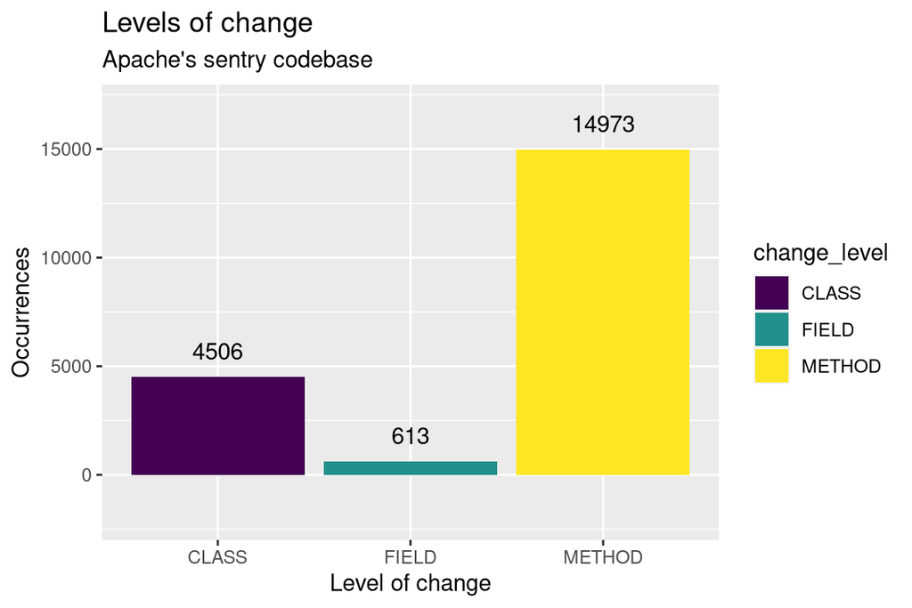

### Changes at the file level

Using the change information that we have available, we counted each change per file over the commits. The following info describes the occurrences of changes per file observed overall:

Descriptive statistics of changes at file level

| mean | sd | p0 | p25 | p50 | p75 | p100 |
| --- | --- | --- | --- | --- | --- | --- |
| 109.792 | 265.643 | 1 | 4 | 22 | 69.5 | 2221 |

These can be visualized using a box plot:

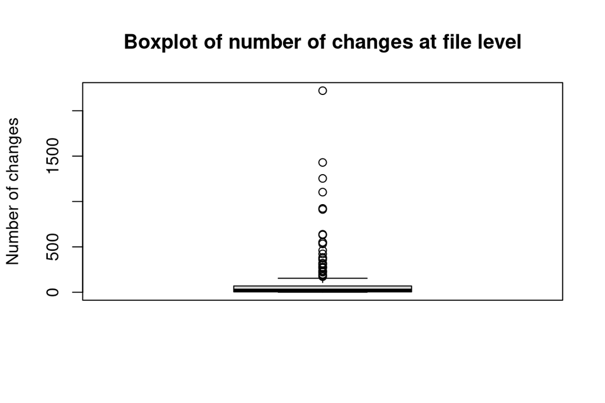

The outliers being:

Table of outliers

| filename | n |
| --- | --- |
| PathsUpdate.java | 2221 |
| TPathsUpdate.java | 1430 |
| TPathsDump.java | 1254 |
| SentryKerberosContext.java | 1103 |
| SentryHdfsMetricsUtil.java | 924 |
| JsonLogEntityFactory.java | 912 |
| SentryHDFSServiceProcessor.java | 639 |
| SentryShellCommon.java | 631 |
| SentryGenericServiceClientDefaultImpl.java | 551 |
| ServiceConstants.java | 549 |
| SentryPolicyServiceClientDefaultImpl.java | 533 |
| HMSFollower.java | 461 |
| SentryPolicyStorePlugin.java | 423 |
| GSSCallback.java | 384 |
| TSentryMappingData.java | 374 |
| DefaultSentryAccessController.java | 356 |
| CommandUtil.java | 320 |
| SentryHDFSService.java | 317 |
| SentryService.java | 303 |
| TListSentryPrivilegesByAuthResponse.java | 278 |
| PermissionsUpdate.java | 277 |
| ResourceAuthorizationProvider.java | 266 |
| TListSentryPrivilegesByAuthRequest.java | 238 |
| TSentryExportMappingDataRequest.java | 228 |
| TSentryHmsEventNotification.java | 221 |
| TListSentryPrivilegesRequest.java | 199 |
| KafkaTSentryPrivilegeConverter.java | 184 |
| TPrivilegeChanges.java | 172 |

### Changes at method/class/access level

Using the method level information available, we counted the changes recorded per method. The following info describes the occurrences of changes per method/class/access observed overall:

Descriptive statistics of changes at method level

| mean | sd | p0 | p25 | p50 | p75 | p100 |
| --- | --- | --- | --- | --- | --- | --- |
| 23.121 | 74.854 | 1 | 2 | 5 | 21 | 1678 |

These can be visualized using a box plot:

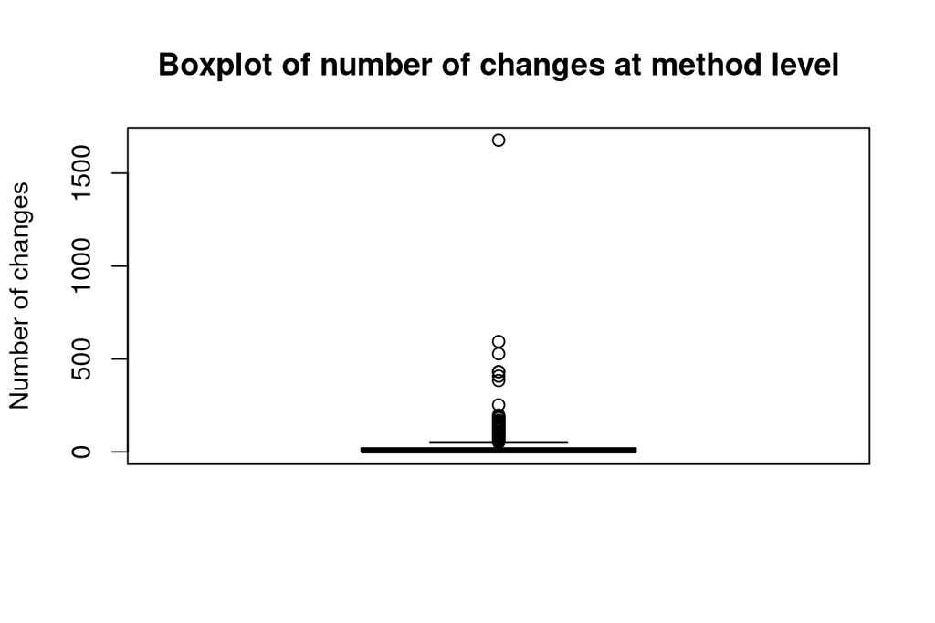

The outliers being:

Table of outliers

| level_name | n |
| --- | --- |
| org.apache.sentry.hdfs.PathsUpdate.parsePath(String) | 1678 |
| org.apache.sentry.provider.db.tools.SentryShellCommon.parseArgs(String[]) | 594 |
| org.apache.sentry.hdfs.SentryHdfsMetricsUtil | 528 |
| org.apache.sentry.service.thrift.SentryKerberosContext.run() | 432 |
| org.apache.sentry.hdfs.PathsUpdate | 431 |
| org.apache.sentry.hdfs.SentryHDFSServiceProcessor.handle_hms_notification(TPathsUpdate) | 408 |
| org.apache.sentry.service.thrift.GSSCallback.allowConnect(String) | 384 |
| org.apache.sentry.hdfs.service.thrift.TPathsDump.TPathsDumpTupleScheme.read(org.apache.thrift.protocol.TProtocol,TPathsDump) | 253 |
| org.apache.sentry.hdfs.service.thrift.TPathsUpdate.TPathsUpdateStandardScheme.read(org.apache.thrift.protocol.TProtocol,TPathsUpdate) | 198 |
| org.apache.sentry.hdfs.PermissionsUpdate | 191 |
| org.apache.sentry.hdfs.service.thrift.TPathsDump.TPathsDumpStandardScheme.read(org.apache.thrift.protocol.TProtocol,TPathsDump) | 187 |
| org.apache.sentry.provider.db.service.thrift.SentryPolicyServiceClientDefaultImpl | 185 |
| org.apache.sentry.provider.db.generic.tools.KafkaTSentryPrivilegeConverter.validatePrivilegeHierarchy(String) | 184 |
| org.apache.sentry.hdfs.SentryHDFSServiceProcessor.get_all_authz_updates_from(long,long) | 182 |
| org.apache.sentry.hdfs.service.thrift.TPathsUpdate | 168 |
| org.apache.sentry.hdfs.ServiceConstants.ServerConfig | 168 |
| org.apache.sentry.provider.db.log.entity.JsonLogEntityFactory.setCommAttrForAMLE(AuditMetadataLogEntity,Configuration,TSentryResponseStatus,String,String) | 168 |
| org.apache.sentry.service.thrift.SentryKerberosContext.shutDown() | 168 |
| org.apache.sentry.provider.db.generic.service.thrift.SentryGenericServiceClientDefaultImpl | 167 |
| org.apache.sentry.service.thrift.SentryKerberosContext.startRenewerThread() | 160 |
| org.apache.sentry.service.thrift.SentryKerberosContext.SentryKerberosContext(String,String,boolean) | 154 |
| org.apache.sentry.api.service.thrift.TSentryMappingData.TSentryMappingDataStandardScheme.read(org.apache.thrift.protocol.TProtocol,TSentryMappingData) | 148 |
| org.apache.sentry.api.service.thrift.TSentryMappingData.TSentryMappingDataTupleScheme.read(org.apache.thrift.protocol.TProtocol,TSentryMappingData) | 148 |
| org.apache.sentry.hdfs.service.thrift.TPathsUpdate.compareTo(TPathsUpdate) | 147 |
| org.apache.sentry.hdfs.service.thrift.TPathsUpdate.equals(TPathsUpdate) | 147 |
| org.apache.sentry.hdfs.ServiceConstants.ClientConfig | 143 |
| org.apache.sentry.provider.common.ResourceAuthorizationProvider.doHasAccess(Subject,List<? extends Authorizable>,Set<? extends Action>,ActiveRoleSet) | 140 |
| org.apache.sentry.hdfs.ThriftSerializer | 132 |
| org.apache.sentry.service.thrift.SentryKerberosContext | 127 |
| org.apache.sentry.hdfs.service.thrift.TPathsUpdate.setFieldValue(_Fields,Object) | 126 |
| org.apache.sentry.hdfs.service.thrift.TPathsUpdate.toString() | 126 |
| org.apache.sentry.provider.db.service.persistent.HMSFollower.syncupWithHms(long) | 124 |
| org.apache.sentry.hdfs.service.thrift.TPathsDump | 121 |
| org.apache.sentry.hdfs.service.thrift.TPathsDump.TPathsDumpStandardScheme.write(org.apache.thrift.protocol.TProtocol,TPathsDump) | 121 |
| org.apache.sentry.hdfs.service.thrift.TPathsDump.TPathsDumpTupleScheme.write(org.apache.thrift.protocol.TProtocol,TPathsDump) | 121 |
| org.apache.sentry.provider.db.SentryPolicyStorePlugin.onAlterSentryRoleGrantPrivilege(TAlterSentryRoleGrantPrivilegeRequest) | 110 |
| org.apache.sentry.provider.db.SentryPolicyStorePlugin.onAlterSentryRoleRevokePrivilege(TAlterSentryRoleRevokePrivilegeRequest) | 110 |
| org.apache.sentry.hdfs.SentryUpdater.getUpdates() | 108 |
| org.apache.sentry.hdfs.service.thrift.TPathsUpdate.TPathsUpdateTupleScheme.write(org.apache.thrift.protocol.TProtocol,TPathsUpdate) | 107 |
| org.apache.sentry.core.common.utils.SentryConstants | 105 |
| org.apache.sentry.provider.common.ResourceAuthorizationProvider.hasAccess(Subject,List<? extends Authorizable>,Set<? extends Action>,ActiveRoleSet) | 104 |
| org.apache.sentry.hdfs.Updateable.Update | 102 |
| org.apache.sentry.provider.db.service.thrift.SentryWebServer.SentryWebServer(List<EventListener>,int,Configuration) | 101 |
| org.apache.sentry.hdfs.service.thrift.TPathsDump.toString() | 99 |
| org.apache.sentry.provider.db.generic.service.thrift.SentryGenericServiceClientDefaultImpl.connect() | 99 |
| org.apache.sentry.provider.db.log.entity.JsonLogEntityFactory | 96 |
| org.apache.sentry.hdfs.service.thrift.TPathsUpdate.TPathsUpdateTupleScheme.read(org.apache.thrift.protocol.TProtocol,TPathsUpdate) | 94 |
| org.apache.sentry.provider.db.log.util.CommandUtil.createCmdForGrantOrRevokeGMPrivilege(String,org.apache.sentry.provider.db.generic.service.thrift.TSentryPrivilege,boolean) | 92 |
| org.apache.sentry.provider.db.log.entity.JsonLogEntityFactory.createJsonLogEntity(org.apache.sentry.provider.db.generic.service.thrift.TAlterSentryRoleAddGroupsRequest,org.apache.sentry.provider.db.ge… | 90 |
| org.apache.sentry.provider.db.log.entity.JsonLogEntityFactory.createJsonLogEntity(org.apache.sentry.provider.db.generic.service.thrift.TAlterSentryRoleDeleteGroupsRequest,org.apache.sentry.provider.db… | 90 |
| org.apache.sentry.provider.db.log.entity.JsonLogEntityFactory.createJsonLogEntity(org.apache.sentry.provider.db.generic.service.thrift.TAlterSentryRoleGrantPrivilegeRequest,org.apache.sentry.provider.… | 90 |
| org.apache.sentry.provider.db.log.entity.JsonLogEntityFactory.createJsonLogEntity(org.apache.sentry.provider.db.generic.service.thrift.TAlterSentryRoleRevokePrivilegeRequest,org.apache.sentry.provider… | 90 |
| org.apache.sentry.provider.db.log.entity.JsonLogEntityFactory.createJsonLogEntity(org.apache.sentry.provider.db.generic.service.thrift.TCreateSentryRoleRequest,org.apache.sentry.provider.db.generic.se… | 90 |
| org.apache.sentry.provider.db.log.entity.JsonLogEntityFactory.createJsonLogEntity(org.apache.sentry.provider.db.generic.service.thrift.TDropSentryRoleRequest,org.apache.sentry.provider.db.generic.serv… | 90 |
| org.apache.sentry.provider.db.generic.service.thrift.SentryGenericServiceClientDefaultImpl.SentryGenericServiceClientDefaultImpl(Configuration,SentryPolicyClientTransportConfig) | 88 |
| org.apache.sentry.hdfs.service.thrift.TPathsUpdate.TPathsUpdateStandardScheme.write(org.apache.thrift.protocol.TProtocol,TPathsUpdate) | 86 |
| org.apache.sentry.hdfs.service.thrift.TPathsUpdate.hashCode() | 84 |
| org.apache.sentry.service.thrift.SentryService.startHMSFollower(Configuration) | 82 |
| org.apache.sentry.hdfs.service.thrift.TPathsDump.compareTo(TPathsDump) | 77 |
| org.apache.sentry.hdfs.service.thrift.TPathsDump.equals(TPathsDump) | 77 |
| org.apache.sentry.provider.db.SentryPolicyStorePlugin | 72 |
| org.apache.sentry.provider.db.generic.service.thrift.SentryGenericServiceClientDefaultImpl.SentryGenericServiceClientDefaultImpl(Configuration) | 70 |
| org.apache.sentry.hdfs.SentryHDFSServiceClientDefaultImpl.SentryHDFSServiceClientDefaultImpl(Configuration) | 68 |
| org.apache.sentry.api.service.thrift.TListSentryPrivilegesByAuthResponse.TListSentryPrivilegesByAuthResponseStandardScheme.read(org.apache.thrift.protocol.TProtocol,TListSentryPrivilegesByAuthResponse… | 66 |
| org.apache.sentry.hdfs.service.thrift.TPathsDump.setFieldValue(_Fields,Object) | 66 |
| org.apache.sentry.provider.db.service.thrift.SentryPolicyServiceClientDefaultImpl.connect() | 66 |
| org.apache.sentry.provider.db.service.thrift.SentryPolicyServiceClientDefaultImpl.SentryPolicyServiceClientDefaultImpl(Configuration,SentryPolicyClientTransportConfig) | 66 |
| org.apache.sentry.service.thrift.SentryService.SentryService(Configuration) | 66 |
| org.apache.sentry.hdfs.service.thrift.SentryHDFSService.Client | 63 |
| org.apache.sentry.service.thrift.SentryServiceUtil | 63 |
| org.apache.sentry.service.thrift.SentryServiceUtil.isHDFSSyncEnabled(Configuration) | 63 |
| org.apache.sentry.service.thrift.SentryKerberosContext.getRefreshTime(KerberosTicket) | 62 |
| org.apache.sentry.service.thrift.SentryService.stopHMSFollower(Configuration) | 60 |
| org.apache.sentry.service.thrift.ServiceConstants.ServerConfig | 60 |
| org.apache.sentry.api.service.thrift.TListSentryPrivilegesByAuthRequest.TListSentryPrivilegesByAuthRequestTupleScheme.read(org.apache.thrift.protocol.TProtocol,TListSentryPrivilegesByAuthRequest) | 56 |
| org.apache.sentry.binding.hive.authz.DefaultSentryAccessController.showPrivileges(HivePrincipal,HivePrivilegeObject) | 56 |
| org.apache.sentry.api.service.thrift.TListSentryPrivilegesByAuthResponse.TListSentryPrivilegesByAuthResponseTupleScheme.read(org.apache.thrift.protocol.TProtocol,TListSentryPrivilegesByAuthResponse) | 54 |
| org.apache.sentry.hdfs.SentryHDFSServiceClient | 53 |

### Coupled changes

Here we used the info we got from the coupled changes analysis.

#### File level

Using the cochange information available, we counted the changes recorded per file. The following info describes the occurrences of changes per file observed overall:

Descriptive statistics of cochanges at file level

| mean | sd | p0 | p25 | p50 | p75 | p100 |
| --- | --- | --- | --- | --- | --- | --- |
| 5.995 | 3.084 | 1 | 3 | 8 | 9 | 10 |

These can be visualized using a box plot:

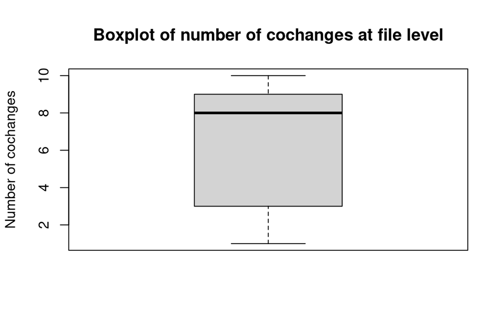

The outliers being:

Table of outliers

| filename.x | n |
| --- | --- |

#### Method level

Using the co-change information available, we counted the changes recorded per method. The following info describes the occurrences of changes per method observed overall:

Descriptive statistics of cochanges at method level

| mean | sd | p0 | p25 | p50 | p75 | p100 |
| --- | --- | --- | --- | --- | --- | --- |
| 31.947 | 15.647 | 1 | 26 | 32 | 46 | 55 |

These can be visualized using a box plot:

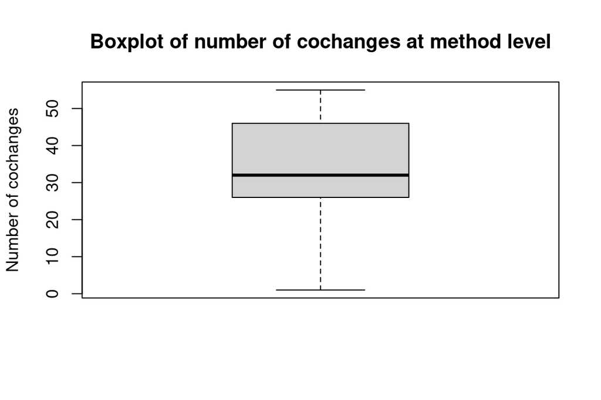

The outliers being:

Table of outliers

| level_name.x | n |
| --- | --- |

## Deeper analysis

In order to get some insight over the data, the following information was researched:

- Types of changes in the most frequently changed files
- Types of changes in the most frequently co-changed files
- Types of changes in the most frequently changed methods
- Types of changes in the most frequently co-changed methods
- Frequency of changes over time in frequently changed files
- Frequency of changes over time in frequently co-changed files
- Frequency of changes over time in frequently changed methods
- Frequency of changes over time in frequently co-changed methods

### Types of changes in the most frequently changed files

We selected the 90 percentile most changed files and recorded the frequency of the types of changes recorded.

Frecuencies of type of changes per files for top 90 percentile

| change | n |
| --- | --- |
| STATEMENT_DELETE | 2930 |
| STATEMENT_INSERT | 2768 |
| STATEMENT_UPDATE | 867 |
| STATEMENT_PARENT_CHANGE | 862 |
| REMOVED_OBJECT_STATE | 752 |
| ADDITIONAL_OBJECT_STATE | 736 |
| PARAMETER_TYPE_CHANGE | 723 |
| REMOVED_FUNCTIONALITY | 611 |
| CONDITION_EXPRESSION_CHANGE | 555 |
| ADDITIONAL_FUNCTIONALITY | 400 |
| DECREASING_ACCESSIBILITY_CHANGE | 226 |
| INCREASING_ACCESSIBILITY_CHANGE | 221 |
| PARAMETER_DELETE | 218 |
| ALTERNATIVE_PART_DELETE | 186 |
| ATTRIBUTE_RENAMING | 156 |
| ALTERNATIVE_PART_INSERT | 138 |
| COMMENT_DELETE | 138 |
| DOC_UPDATE | 134 |
| METHOD_RENAMING | 123 |
| RETURN_TYPE_DELETE | 110 |
| STATEMENT_ORDERING_CHANGE | 109 |
| COMMENT_INSERT | 98 |
| PARAMETER_INSERT | 96 |
| DOC_DELETE | 93 |
| COMMENT_UPDATE | 77 |
| COMMENT_MOVE | 57 |
| REMOVED_CLASS | 56 |
| ADDITIONAL_CLASS | 54 |
| PARAMETER_RENAMING | 27 |
| PARENT_INTERFACE_DELETE | 27 |
| ATTRIBUTE_TYPE_CHANGE | 24 |
| RETURN_TYPE_CHANGE | 24 |
| ADDING_CLASS_DERIVABILITY | 22 |
| PARENT_INTERFACE_INSERT | 22 |
| REMOVING_CLASS_DERIVABILITY | 22 |
| REMOVING_ATTRIBUTE_MODIFIABILITY | 9 |
| DOC_INSERT | 6 |
| PARAMETER_ORDERING_CHANGE | 4 |
| RETURN_TYPE_INSERT | 2 |
| UNCLASSIFIED_CHANGE | 2 |

### Types of changes in the most frequently co-changed files

We selected the 90 percentile most co-changed files and recorded the frequency of the types of changes recorded.

Frecuencies of type of cochanges per files for top 90 percentile

| change | n |
| --- | --- |
| STATEMENT_INSERT | 170 |
| REMOVED_FUNCTIONALITY | 135 |
| STATEMENT_UPDATE | 100 |
| ADDITIONAL_FUNCTIONALITY | 80 |
| STATEMENT_DELETE | 70 |
| REMOVED_OBJECT_STATE | 68 |
| ADDITIONAL_OBJECT_STATE | 62 |
| METHOD_RENAMING | 36 |
| RETURN_TYPE_CHANGE | 34 |
| PARAMETER_DELETE | 26 |
| PARENT_INTERFACE_DELETE | 25 |
| PARAMETER_INSERT | 24 |
| UNCLASSIFIED_CHANGE | 23 |
| DOC_UPDATE | 20 |
| STATEMENT_PARENT_CHANGE | 18 |
| DECREASING_ACCESSIBILITY_CHANGE | 16 |
| PARAMETER_TYPE_CHANGE | 14 |
| PARAMETER_RENAMING | 12 |
| ATTRIBUTE_TYPE_CHANGE | 11 |
| PARENT_INTERFACE_INSERT | 11 |
| COMMENT_DELETE | 5 |
| DOC_DELETE | 3 |
| ADDITIONAL_CLASS | 2 |
| INCREASING_ACCESSIBILITY_CHANGE | 2 |
| REMOVING_ATTRIBUTE_MODIFIABILITY | 2 |
| RETURN_TYPE_INSERT | 2 |
| COMMENT_INSERT | 1 |
| DOC_INSERT | 1 |

### Types of changes in the most frequently changed methods

We selected the 90 percentile most changed methods and recorded the frequency of the types of changes recorded.

Frecuencies of type of changes per method for top 90 percentile

| change | n |
| --- | --- |
| STATEMENT_DELETE | 3100 |
| STATEMENT_INSERT | 2567 |
| REMOVED_OBJECT_STATE | 806 |
| STATEMENT_UPDATE | 760 |
| ADDITIONAL_OBJECT_STATE | 758 |
| REMOVED_FUNCTIONALITY | 756 |
| STATEMENT_PARENT_CHANGE | 756 |
| PARAMETER_TYPE_CHANGE | 608 |
| ADDITIONAL_FUNCTIONALITY | 548 |
| CONDITION_EXPRESSION_CHANGE | 509 |
| PARAMETER_DELETE | 207 |
| ALTERNATIVE_PART_DELETE | 184 |
| ALTERNATIVE_PART_INSERT | 143 |
| COMMENT_DELETE | 138 |
| STATEMENT_ORDERING_CHANGE | 112 |
| DOC_UPDATE | 103 |
| COMMENT_INSERT | 91 |
| PARAMETER_INSERT | 90 |
| DOC_DELETE | 84 |
| COMMENT_UPDATE | 70 |
| COMMENT_MOVE | 51 |
| INCREASING_ACCESSIBILITY_CHANGE | 49 |
| DECREASING_ACCESSIBILITY_CHANGE | 39 |
| PARENT_INTERFACE_DELETE | 38 |
| PARAMETER_RENAMING | 26 |
| RETURN_TYPE_CHANGE | 24 |
| ADDING_CLASS_DERIVABILITY | 22 |
| PARENT_INTERFACE_INSERT | 22 |
| REMOVING_CLASS_DERIVABILITY | 22 |
| ADDITIONAL_CLASS | 4 |

### Types of changes in the most frequently co-changed methods

We selected the 90 percentile most co-changed methods and recorded the frequency of the types of changes recorded.

Frecuencies of type of cochanges per method for top 90 percentile

| change | n |
| --- | --- |
| DECREASING_ACCESSIBILITY_CHANGE | 217 |
| INCREASING_ACCESSIBILITY_CHANGE | 191 |
| STATEMENT_UPDATE | 181 |
| REMOVED_OBJECT_STATE | 138 |
| REMOVED_FUNCTIONALITY | 111 |
| PARAMETER_TYPE_CHANGE | 93 |
| STATEMENT_DELETE | 91 |
| ADDITIONAL_FUNCTIONALITY | 84 |
| STATEMENT_INSERT | 82 |
| METHOD_RENAMING | 72 |
| ADDITIONAL_OBJECT_STATE | 59 |
| ATTRIBUTE_RENAMING | 32 |
| RETURN_TYPE_CHANGE | 23 |
| UNCLASSIFIED_CHANGE | 23 |
| PARAMETER_INSERT | 22 |
| REMOVED_CLASS | 22 |
| ADDITIONAL_CLASS | 20 |
| DOC_DELETE | 13 |
| DOC_INSERT | 11 |
| CONDITION_EXPRESSION_CHANGE | 1 |
| PARENT_INTERFACE_DELETE | 1 |

### Frequency of changes over time in frequently changed files

Tracking the number of changes over time for the most changed files and found the following trends:

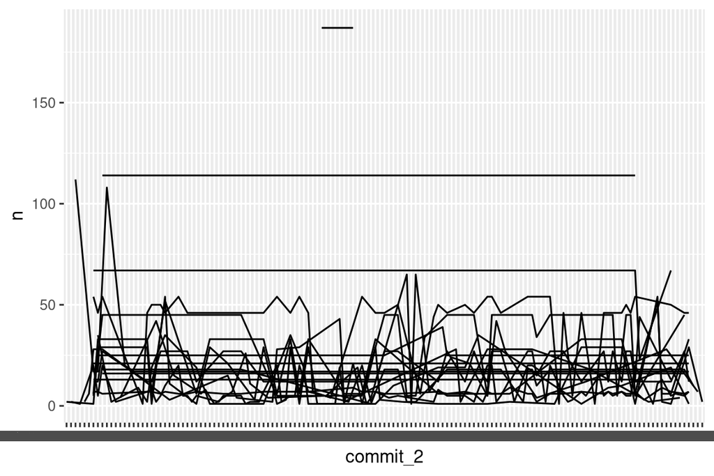

### Frequency of changes over time in frequently co-changed files

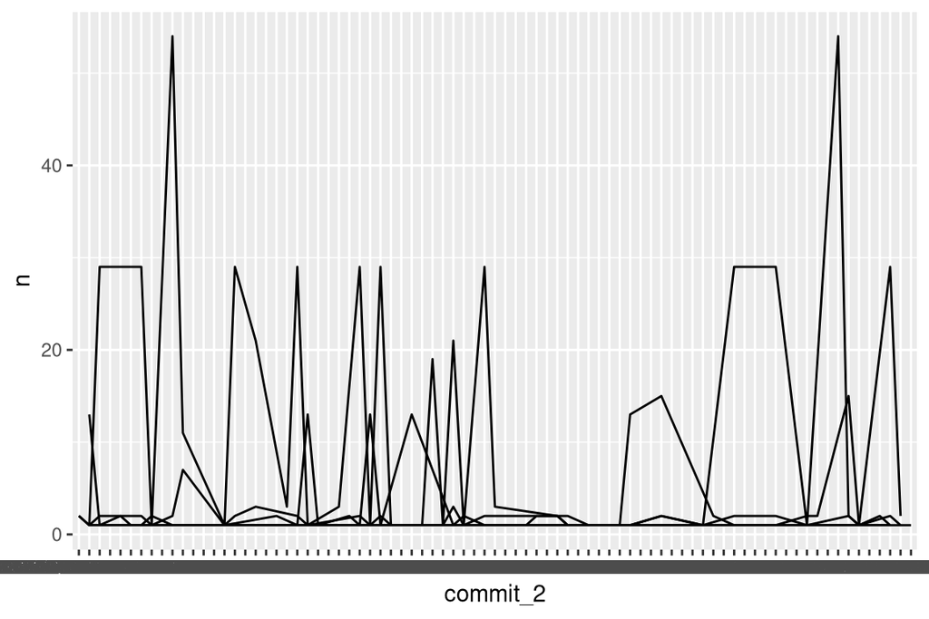

### Frequency of changes over time in frequently changed methods

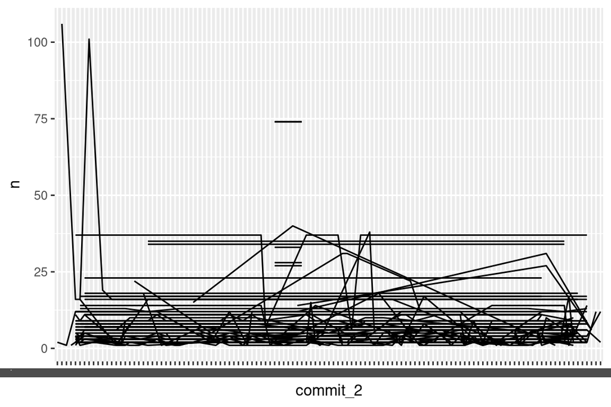

### Frequency of changes over time in frequently co-changed methods

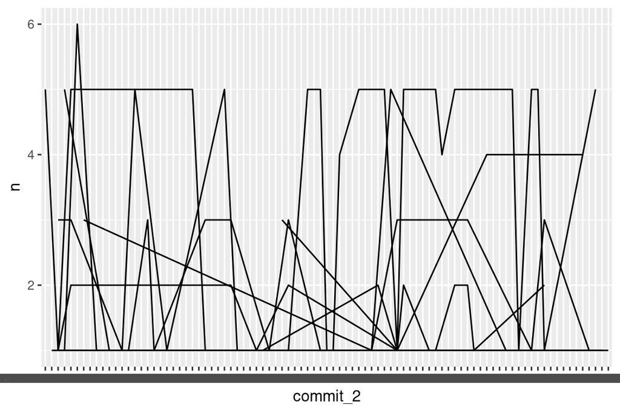